# **Malaria Detection**

### **Visualize the images with subplot(6, 6) and figsize = (12, 12)**

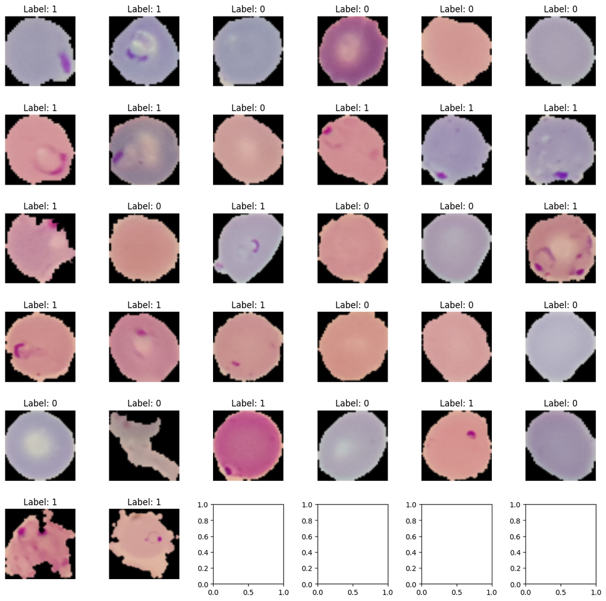

```python
# Get a batch of images and their labels
images, labels = next(iter(train_dataloader_custom))

# Visualize the images using a 6x6 subplot
fig, axes = plt.subplots(6, 6, figsize=(12, 12))

for i, ax in enumerate(axes.flatten()):
    if i >= len(images):
        break
    imshow(images[i], ax)
    ax.set_title(f"Label: {labels[i].item()}")
    ax.axis("off")

plt.tight_layout()
plt.show()
```

#### **Observations and insights:**

Further examination of more images reveals that the shape of parasites may quite vary from oval over oval to branched. Moreover, under different hue and brightness, parasites exhibit different signal strength.

- HSV conversion that separates hue, saturation and value (intensity) of color an be more robust to lighting variations and shadows.

### **Plotting the mean images for parasitized and uninfected**

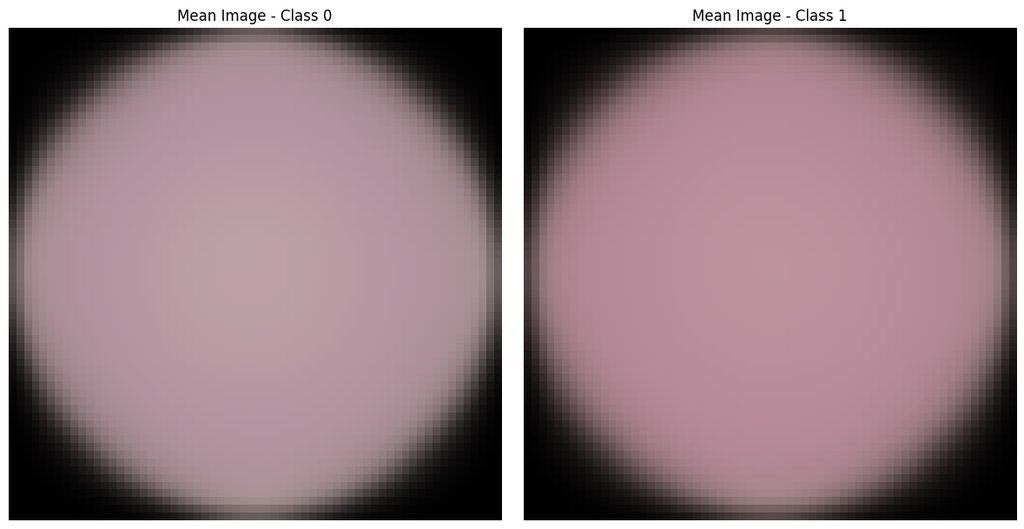

```python
mean_images = calculate_mean_images(train_dataloader_custom)

# Plot mean images for class 0 and class 1
fig, axes = plt.subplots(1, 2, figsize=(12, 6))

for i, (label, img) in enumerate(mean_images.items()):
    imshow(img, axes[i])
    axes[i].set_title(f"Mean Image - Class {label}")
    axes[i].axis("off")

plt.tight_layout()
plt.show()
```

#### **Observations and insights:**

Visualizing the mean image provided insights into the overall structure, patterns, and trends within a dataset. By examining the mean image, the common features shared by images in each class were identified. Mean image for the parasitized sample shows more intense hue than the mean image for the uninfected class.

- It might be helpful for understanding the data and designing appropriate models or features.
- It confirms the prominent role of color.

### **Converting RGB to HSV of Images using OpenCV**

### **Converting the train data**

```python
# Create the custom dataset objects for train and test data
train_data_hsv = HSVImageDataset(train_data_custom)
```

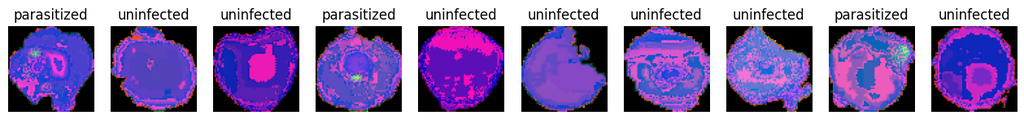

```python
display_random_images(dataset=train_data_hsv,
                      classes=["uninfected", "parasitized"],
                      n=10,
                      display_shape=False,
                      seed=42)
```

### **Converting the test data**

```python
# Create the custom dataset objects for train and test data
test_data_hsv = HSVImageDataset(test_data_custom)
```

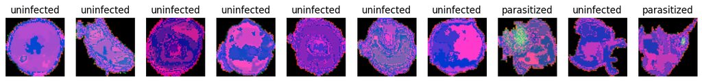

```python
display_random_images(dataset=test_data_hsv,
                      classes=["uninfected", "parasitized"],
                      n=10,
                      display_shape=False,
                      seed=42)
```

#### **Observations and insights:**

Converting RGB to HSV reveals parasites inside red blood cells as differently colored spots.

- HSV representation is more robust to lighting variations and shadows, as the Hue component remains relatively stable under different lighting conditions. This makes it easier to identify and track objects based on their color, regardless of the illumination or shadows present in the scene.
- Some image processing tasks, such as edge detection, noise reduction, or color-based filtering, benefit from working in the HSV color space, as it can lead to more accurate and meaningful results.
- The HSV color space provides a better representation of how humans perceive colors, as it separates the color information (Hue) from the intensity (Value) and the saturation of the color. This can help in designing algorithms that better mimic human perception, which may improve the performance of computer vision tasks.

### **Processing Images using Gaussian Blurring**

### **Gaussian Blurring on train data**

```python
# Create the custom dataset objects for train and test data with Gaussian blurring
train_data_blurred = GaussianBlurDataset(train_data_custom, kernel_size=5, sigma=0)
```

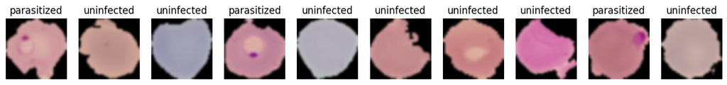

```python
display_random_images(dataset=train_data_blurred,
                      classes=["uninfected", "parasitized"],
                      n=10,
                      display_shape=False,
                      seed=42)
```

### **Gaussian Blurring on test data**

```python
# Create the custom dataset objects for train and test data with Gaussian blurring
test_data_blurred = GaussianBlurDataset(test_data_custom, kernel_size=5, sigma=0)
```

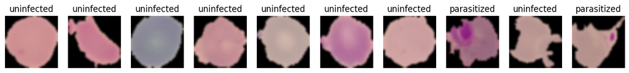

```python
display_random_images(dataset=test_data_blurred,
                      classes=["uninfected", "parasitized"],
                      n=10,
                      display_shape=False,
                      seed=42)
```

#### **Observations and insights:**

Blurred images appear to have lost the sharp definition of the parasite inside red blood cells. Moreover, less defined parasites in images of different quality and brightness could be entirely lost from detection.

**Think About It:** Would blurring help us for this problem statement in any way? What else can we try?

Gaussian blurring could potentially help with malaria detection from microscopic images, but its effectiveness depends on the specific problem and dataset at hand. There are several ways Gaussian blurring could be beneficial, but mainly noise reduction. Microscopic images often contain noise due to the imaging process or the equipment used. Gaussian blurring can help reduce this noise, leading to cleaner images that are easier to analyze and process.

On the other hand, it's important to note that Gaussian blurring also has some drawbacks in malaria detection. Gaussian blurring can cause a loss of fine details in the image, which might be crucial for detecting subtle signs of malaria infection. Excessive blurring leads to over-smoothing of the image, making it more challenging to identify specific features related to malaria infection. Moreover, Gaussian blurring needs extensive fine-tuning to hit the precise trade-off between the advantages and disadvantages.

Apart from Gaussian blurring, there are several other preprocessing and feature extraction techniques that can be helpful in malaria detection from microscopic images. Some of these techniques are:

- Image enhancement and segmentation
- Data augmentation
- Convolutional Neural Networks can be trained on the dataset to automatically learn features and perform classification tasks.
- Pretrained deep learning models, such as ResNet or VGG, can be fine-tuned on the malaria dataset to leverage the features learned from large-scale datasets like ImageNet.
- Combining the predictions from multiple models or techniques (ensemble methods) can improve overall performance and increase the robustness of the malaria detection system.

## **Model Building**

### **Base Model**

**Note:** The Base Model has been fully built and evaluated with all outputs shown to give an idea about the process of the creation and evaluation of the performance of a CNN architecture. A similar process can be followed in iterating to build better-performing CNN architectures.

### **Importing the required libraries for building and training our Model**

```python
import torch
import torch.nn as nn
import torch.optim as optim
from torchinfo import summary

from sklearn.metrics import confusion_matrix, precision_recall_fscore_support

import numpy as np

import matplotlib.pyplot as plt
import seaborn as sns
```

### **Building the model**

```python
class BaseModel(nn.Module):
    def __init__(self):
        super(BaseModel, self).__init__()

    def forward(self, x):
        raise NotImplementedError

    def train_model(self, train_loader, val_loader, criterion, optimizer, device, num_epochs):
        "Trains the model and stores accuracies for train and validation data loaders for each epoch."
        self.to(device)
        train_accuracies = []
        val_accuracies = []

        for epoch in range(num_epochs):
            self.train()
            running_loss = 0.0

            # Train
            for i, (inputs, labels) in enumerate(train_loader):
                inputs, labels = inputs.to(device), labels.to(device)
                optimizer.zero_grad()
                outputs = self(inputs)
                loss = criterion(outputs, labels)
                loss.backward()
                optimizer.step()
                running_loss += loss.item()


            _, train_accuracy = self.evaluate_model(train_loader, device)
            _, val_accuracy = self.evaluate_model(val_loader, device)

            train_accuracies.append(train_accuracy)
            val_accuracies.append(val_accuracy)

            print(f"Epoch [{epoch + 1}/{num_epochs}] Train Accuracy: {train_accuracy:.4f}, Val Accuracy: {val_accuracy:.4f}")

        return train_accuracies, val_accuracies

    def evaluate_model(self, test_loader, device):
        "Evaluates the model with basic performance metrics and confusion matrix."
        self.eval()
        self.to(device)
        all_labels = []
        all_predicted = []

        with torch.no_grad():
            for inputs, labels in test_loader:
                inputs, labels = inputs.to(device), labels.to(device)
                outputs = self(inputs)
                _, predicted = torch.max(outputs.data, 1)
                all_labels.extend(labels.cpu().numpy())
                all_predicted.extend(predicted.cpu().numpy())

        accuracy = (np.array(all_labels) == np.array(all_predicted)).mean()
        precision, recall, f1_score, _ = precision_recall_fscore_support(all_labels, all_predicted, average='weighted')
        cm = confusion_matrix(all_labels, all_predicted)

        print(f"Accuracy: {accuracy:.4f}")
        print(f"Precision: {precision:.4f}")
        print(f"Recall: {recall:.4f}")
        print(f"F1 Score: {f1_score:.4f}")

        return cm, accuracy

    def plot_accuracy_curves(self, train_accuracies, val_accuracies):
        "Plots accuracy curves."
        plt.figure()
        plt.plot(train_accuracies, label='Train Accuracy')
        plt.plot(val_accuracies, label='Validation Accuracy')
        plt.xlabel('Epoch')
        plt.ylabel('Accuracy')
        plt.legend()
        plt.show()

    def plot_confusion_matrix(self, cm, class_names):
        "Plots confusion matrices."
        plt.figure(figsize=(10, 7))
        sns.heatmap(cm, annot=True, fmt="d", cmap="Blues", xticklabels=class_names, yticklabels=class_names)
        plt.xlabel("Predicted")
        plt.ylabel("True")
        plt.title("Confusion Matrix")
        plt.show()

class SimpleCNN(BaseModel):
    def __init__(self, num_classes):
        super(SimpleCNN, self).__init__()

        # First convolutional layer
        self.conv1 = nn.Conv2d(3, 32, kernel_size=2, stride=1, padding=1)
        self.relu1 = nn.ReLU()
        self.pool1 = nn.MaxPool2d(kernel_size=2)
        self.dropout1 = nn.Dropout(0.2)

        # Second convolutional layer
        self.conv2 = nn.Conv2d(32, 32, kernel_size=2, stride=1, padding=1)
        self.relu2 = nn.ReLU()
        self.pool2 = nn.MaxPool2d(kernel_size=2)
        self.dropout2 = nn.Dropout(0.2)

        # Third convolutional layer
        self.conv3 = nn.Conv2d(32, 32, kernel_size=2, stride=1, padding=1)
        self.relu3 = nn.ReLU()
        self.pool3 = nn.MaxPool2d(kernel_size=2)
        self.dropout3 = nn.Dropout(0.2)

        # Fully-connected layers
        self.fc1 = nn.Linear(32 * 8 * 8, 512)
        self.relu = nn.ReLU()
        self.dropout = nn.Dropout(0.4)

        self.fc2 = nn.Linear(512, num_classes)
        self.softmax = nn.Softmax(dim=1)

    def forward(self, x):

        x = self.dropout1(self.pool1(self.relu1(self.conv1(x))))
        x = self.dropout2(self.pool2(self.relu2(self.conv2(x))))
        x = self.dropout3(self.pool3(self.relu3(self.conv3(x))))

        x = x.view(x.size(0), -1) # flatten

        x = self.dropout(self.relu(self.fc1(x)))
        x = self.softmax(self.fc2(x))

        return x
```

### **Fit and train our Model**

```python
# Set the seed to a fixed value
torch.manual_seed(42)

# Set the flag to True
torch.backends.cudnn.deterministic = True

device = torch.device("cuda" if torch.cuda.is_available() else "cpu")
num_classes = 2  # Number of classes in your classification task
model_0 = SimpleCNN(num_classes)

criterion = nn.CrossEntropyLoss()
optimizer = optim.Adam(model_0.parameters(), lr=0.001)
num_epochs = 20

summary(model_0, input_size=(32, 3, 64, 64))
```

```
==========================================================================================
Layer (type:depth-idx)                   Output Shape              Param #
==========================================================================================
SimpleCNN                                [32, 2]                   --
├─Conv2d: 1-1                            [32, 32, 65, 65]          416
├─ReLU: 1-2                              [32, 32, 65, 65]          --
├─MaxPool2d: 1-3                         [32, 32, 32, 32]          --
├─Dropout: 1-4                           [32, 32, 32, 32]          --
├─Conv2d: 1-5                            [32, 32, 33, 33]          4,128
├─ReLU: 1-6                              [32, 32, 33, 33]          --
├─MaxPool2d: 1-7                         [32, 32, 16, 16]          --
├─Dropout: 1-8                           [32, 32, 16, 16]          --
├─Conv2d: 1-9                            [32, 32, 17, 17]          4,128
├─ReLU: 1-10                             [32, 32, 17, 17]          --
├─MaxPool2d: 1-11                        [32, 32, 8, 8]            --
├─Dropout: 1-12                          [32, 32, 8, 8]            --
├─Linear: 1-13                           [32, 512]                 1,049,088
├─ReLU: 1-14                             [32, 512]                 --
├─Dropout: 1-15                          [32, 512]                 --
├─Linear: 1-16                           [32, 2]                   1,026
├─Softmax: 1-17                          [32, 2]                   --
==========================================================================================
Total params: 1,058,786
Trainable params: 1,058,786
Non-trainable params: 0
Total mult-adds (M): 271.88
==========================================================================================
Input size (MB): 1.57
Forward/backward pass size (MB): 46.03
Params size (MB): 4.24
Estimated Total Size (MB): 51.84
==========================================================================================
```

```python
# Set the seed to a fixed value
torch.manual_seed(42)

train_accuracies, val_accuracies = model_0.train_model(train_dataloader_custom, val_dataloader_custom, criterion, optimizer, device, num_epochs)
```

```
Accuracy: 0.9419
Precision: 0.9420
Recall: 0.9419
F1 Score: 0.9419
Accuracy: 0.9381
Precision: 0.9383
Recall: 0.9381
F1 Score: 0.9381
Epoch [1/20] Train Accuracy: 0.9419, Val Accuracy: 0.9381
Accuracy: 0.9365
Precision: 0.9399
Recall: 0.9365
F1 Score: 0.9365
Accuracy: 0.9361
Precision: 0.9395
Recall: 0.9361
F1 Score: 0.9360
Epoch [2/20] Train Accuracy: 0.9365, Val Accuracy: 0.9361
Accuracy: 0.9441
Precision: 0.9448
Recall: 0.9441
F1 Score: 0.9441
Accuracy: 0.9429
Precision: 0.9437
Recall: 0.9429
F1 Score: 0.9429
Epoch [3/20] Train Accuracy: 0.9441, Val Accuracy: 0.9429
Accuracy: 0.9516
Precision: 0.9518
Recall: 0.9516
F1 Score: 0.9516
Accuracy: 0.9515
Precision: 0.9517
Recall: 0.9515
F1 Score: 0.9515
Epoch [4/20] Train Accuracy: 0.9516, Val Accuracy: 0.9515
Accuracy: 0.9543
Precision: 0.9543
Recall: 0.9543
F1 Score: 0.9543
```

[output cut: 125 more lines]

```
F1 Score: 0.9693
Accuracy: 0.9685
Precision: 0.9697
Recall: 0.9685
F1 Score: 0.9685
Epoch [19/20] Train Accuracy: 0.9693, Val Accuracy: 0.9685
Accuracy: 0.9743
Precision: 0.9745
Recall: 0.9743
F1 Score: 0.9743
Accuracy: 0.9720
Precision: 0.9722
Recall: 0.9720
F1 Score: 0.9720
Epoch [20/20] Train Accuracy: 0.9743, Val Accuracy: 0.9720
```

### **Evaluating the model on test data**

**Plotting the confusion matrix**

```
Accuracy: 0.9762
Precision: 0.9762
Recall: 0.9762
F1 Score: 0.9762
```

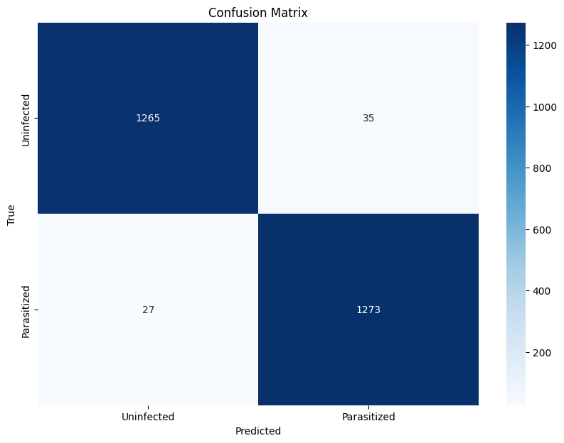

```python
# Set the seed to a fixed value
torch.manual_seed(42)

cm, _ = model_0.evaluate_model(test_dataloader_custom, device)
class_names = ["Uninfected", "Parasitized"]
model_0.plot_confusion_matrix(cm, class_names)
```

**Plotting the train and validation curves**

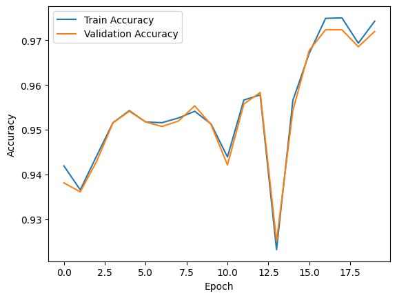

```python
model_0.plot_accuracy_curves(train_accuracies, val_accuracies)
```

So now let's try to build another model with few more add on layers and try to check if we can try to improve the model. Therefore try to build a model by adding few layers if required and altering the activation functions.

### **Model 1**

#### **Trying to improve the performance of our model by adding new layers**

```python
# Implementing a model from reference [4] in the introduction
class ComplexCNN(BaseModel):
    def __init__(self, num_classes):
        super(ComplexCNN, self).__init__()

        self.conv1 = nn.Conv2d(in_channels=3, out_channels=18, kernel_size=3, stride=1, padding=2)
        self.maxpool1 = nn.MaxPool2d(kernel_size=2, stride=2)
        self.dropout1 = nn.Dropout2d(p=0.25)

        self.conv2 = nn.Conv2d(in_channels=18, out_channels=72, kernel_size=3, stride=1)
        self.maxpool2 = nn.MaxPool2d(kernel_size=2, stride=2)
        self.dropout2 = nn.Dropout2d(p=0.25)

        self.conv3 = nn.Conv2d(in_channels=72, out_channels=72, kernel_size=3, stride=1)
        self.maxpool3 = nn.MaxPool2d(kernel_size=2, stride=2)
        self.dropout3 = nn.Dropout2d(p=0.25)

        self.conv4 = nn.Conv2d(in_channels=72, out_channels=72, kernel_size=3, stride=1)
        self.maxpool4 = nn.MaxPool2d(kernel_size=2, stride=2)
        self.dropout4 = nn.Dropout2d(p=0.25)

        self.flatten = nn.Flatten()

        self.fc1 = nn.Linear(in_features=288, out_features=72)
        self.dropout5 = nn.Dropout(p=0.5)
        self.fc2 = nn.Linear(in_features=72, out_features=num_classes)

    def forward(self, x):

        x = self.conv1(x)
        x = nn.functional.relu(x)
        x = self.maxpool1(x)
        x = self.dropout1(x)

        x = self.conv2(x)
        x = nn.functional.relu(x)
        x = self.maxpool2(x)
        x = self.dropout2(x)

        x = self.conv3(x)
        x = nn.functional.relu(x)
        x = self.maxpool3(x)
        x = self.dropout3(x)

        x = self.conv4(x)
        x = nn.functional.relu(x)
        x = self.maxpool4(x)
        x = self.dropout4(x)

        x = self.flatten(x)

        x = self.fc1(x)
        x = nn.functional.relu(x)
        x = self.dropout5(x)
        x = self.fc2(x)
        x = nn.functional.softmax(x, dim=1)

        return x
```

[output not shown]

### **Fit and Train the model**

```python
# Set the seed to a fixed value
torch.manual_seed(42)

# Set the flag to True
torch.backends.cudnn.deterministic = True

device = torch.device("cuda" if torch.cuda.is_available() else "cpu")
num_classes = 2
model_1 = ComplexCNN(num_classes)

criterion = nn.CrossEntropyLoss()
optimizer = optim.Adam(model_1.parameters(), lr=0.001)
num_epochs = 20

summary(model_1, input_size=(32, 3, 64, 64))
```

```
==========================================================================================
Layer (type:depth-idx)                   Output Shape              Param #
==========================================================================================
ComplexCNN                               [32, 2]                   --
├─Conv2d: 1-1                            [32, 18, 66, 66]          504
├─MaxPool2d: 1-2                         [32, 18, 33, 33]          --
├─Dropout2d: 1-3                         [32, 18, 33, 33]          --
├─Conv2d: 1-4                            [32, 72, 31, 31]          11,736
├─MaxPool2d: 1-5                         [32, 72, 15, 15]          --
├─Dropout2d: 1-6                         [32, 72, 15, 15]          --
├─Conv2d: 1-7                            [32, 72, 13, 13]          46,728
├─MaxPool2d: 1-8                         [32, 72, 6, 6]            --
├─Dropout2d: 1-9                         [32, 72, 6, 6]            --
├─Conv2d: 1-10                           [32, 72, 4, 4]            46,728
├─MaxPool2d: 1-11                        [32, 72, 2, 2]            --
├─Dropout2d: 1-12                        [32, 72, 2, 2]            --
├─Flatten: 1-13                          [32, 288]                 --
├─Linear: 1-14                           [32, 72]                  20,808
├─Dropout: 1-15                          [32, 72]                  --
├─Linear: 1-16                           [32, 2]                   146
==========================================================================================
Total params: 126,650
Trainable params: 126,650
Non-trainable params: 0
Total mult-adds (M): 708.46
==========================================================================================
Input size (MB): 1.57
Forward/backward pass size (MB): 41.21
Params size (MB): 0.51
Estimated Total Size (MB): 43.29
==========================================================================================
```

```python
# Set the seed to a fixed value
torch.manual_seed(42)

with suppress(AssertionError):
  train_accuracies, val_accuracies = model_1.train_model(train_dataloader_custom, val_dataloader_custom, criterion, optimizer, device, num_epochs)
```

```
Accuracy: 0.9482
Precision: 0.9482
Recall: 0.9482
F1 Score: 0.9482
Accuracy: 0.9489
Precision: 0.9489
Recall: 0.9489
F1 Score: 0.9489
Epoch [1/20] Train Accuracy: 0.9482, Val Accuracy: 0.9489
Accuracy: 0.9548
Precision: 0.9572
Recall: 0.9548
F1 Score: 0.9547
Accuracy: 0.9535
Precision: 0.9560
Recall: 0.9535
F1 Score: 0.9535
Epoch [2/20] Train Accuracy: 0.9548, Val Accuracy: 0.9535
Accuracy: 0.9649
Precision: 0.9660
Recall: 0.9649
F1 Score: 0.9649
Accuracy: 0.9639
Precision: 0.9651
Recall: 0.9639
F1 Score: 0.9639
Epoch [3/20] Train Accuracy: 0.9649, Val Accuracy: 0.9639
Accuracy: 0.9626
Precision: 0.9640
Recall: 0.9626
F1 Score: 0.9626
Accuracy: 0.9621
Precision: 0.9634
Recall: 0.9621
F1 Score: 0.9621
Epoch [4/20] Train Accuracy: 0.9626, Val Accuracy: 0.9621
Accuracy: 0.9648
Precision: 0.9657
Recall: 0.9648
F1 Score: 0.9648
```

[output cut: 125 more lines]

```
F1 Score: 0.9755
Accuracy: 0.9744
Precision: 0.9746
Recall: 0.9744
F1 Score: 0.9744
Epoch [19/20] Train Accuracy: 0.9755, Val Accuracy: 0.9744
Accuracy: 0.9435
Precision: 0.9477
Recall: 0.9435
F1 Score: 0.9434
Accuracy: 0.9391
Precision: 0.9433
Recall: 0.9391
F1 Score: 0.9389
Epoch [20/20] Train Accuracy: 0.9435, Val Accuracy: 0.9391
```

### **Evaluating the model**

**Plotting the confusion matrix**

```
Accuracy: 0.9488
Precision: 0.9512
Recall: 0.9488
F1 Score: 0.9488
```

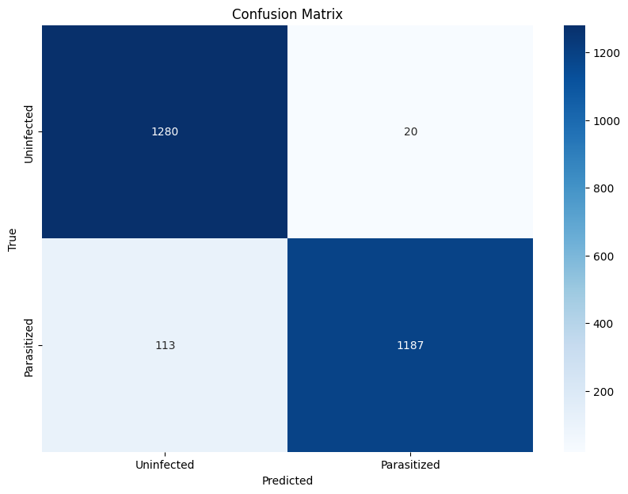

```python
# Set the seed to a fixed value
torch.manual_seed(42)

cm, _ = model_1.evaluate_model(test_dataloader_custom, device)
class_names = ["Uninfected", "Parasitized"]
model_1.plot_confusion_matrix(cm, class_names)
```

**Plotting the train and the validation curves**

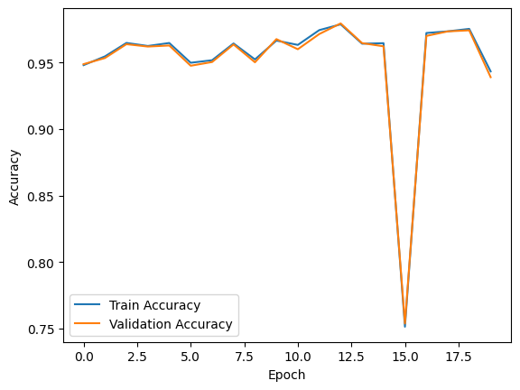

```python
# Set the seed to a fixed value
torch.manual_seed(42)

model_1.plot_accuracy_curves(train_accuracies, val_accuracies)
```

### **Think about it:**

Now let's build a model with LeakyRelu as the activation function

- Can the model performance be improved if we change our activation function to LeakyRelu?
- Can BatchNormalization improve our model?

Let us try to build a model using BatchNormalization and using LeakyRelu as our activation function.

### **Model 2 with Batch Normalization**

```python
class Complex2CNN(BaseModel):
    def __init__(self, num_classes):
        super(Complex2CNN, self).__init__()

        self.conv1 = nn.Conv2d(in_channels=3, out_channels=18, kernel_size=3, stride=1, padding=2)
        self.bn1 = nn.BatchNorm2d(18)
        self.leakyrelu1 = nn.LeakyReLU(inplace=True)
        self.maxpool1 = nn.MaxPool2d(kernel_size=2, stride=2)
        self.dropout1 = nn.Dropout2d(p=0.25)

        self.conv2 = nn.Conv2d(in_channels=18, out_channels=72, kernel_size=3, stride=1)
        self.bn2 = nn.BatchNorm2d(72)
        self.leakyrelu2 = nn.LeakyReLU(inplace=True)
        self.maxpool2 = nn.MaxPool2d(kernel_size=2, stride=2)
        self.dropout2 = nn.Dropout2d(p=0.25)

        self.conv3 = nn.Conv2d(in_channels=72, out_channels=72, kernel_size=3, stride=1)
        self.bn3 = nn.BatchNorm2d(72)
        self.leakyrelu3 = nn.LeakyReLU(inplace=True)
        self.maxpool3 = nn.MaxPool2d(kernel_size=2, stride=2)
        self.dropout3 = nn.Dropout2d(p=0.25)

        self.conv4 = nn.Conv2d(in_channels=72, out_channels=72, kernel_size=3, stride=1)
        self.bn4 = nn.BatchNorm2d(72)
        self.leakyrelu4 = nn.LeakyReLU(inplace=True)
        self.maxpool4 = nn.MaxPool2d(kernel_size=2, stride=2)
        self.dropout4 = nn.Dropout2d(p=0.25)

        self.flatten = nn.Flatten()

        self.fc1 = nn.Linear(in_features=288, out_features=72)
        self.bn5 = nn.BatchNorm1d(72)
        self.leakyrelu5 = nn.LeakyReLU(inplace=True)
        self.dropout5 = nn.Dropout(p=0.5)

        self.fc2 = nn.Linear(in_features=72, out_features=num_classes)
        self.softmax = nn.Softmax(dim=1)

    def forward(self, x):

        x = self.conv1(x)
        x = self.bn1(x)
        x = self.leakyrelu1(x)
        x = self.maxpool1(x)
        x = self.dropout1(x)

        x = self.conv2(x)
        x = self.bn2(x)
        x = self.leakyrelu2(x)
        x = self.maxpool2(x)
        x = self.dropout2(x)

        x = self.conv3(x)
        x = self.bn3(x)
        x = self.leakyrelu3(x)
        x = self.maxpool3(x)
        x = self.dropout3(x)

        x = self.conv4(x)
        x = self.bn4(x)
        x = self.leakyrelu4(x)
        x = self.maxpool4(x)
        x = self.dropout4(x)

        x = self.flatten(x)

        x = self.fc1(x)
        x = self.bn5(x)
        x = self.leakyrelu5(x)
        x = self.dropout5(x)

        x = self.fc2(x)
        x = self.softmax(x)

        return x
```

### **Fit and train the model**

```python
# Set the seed to a fixed value
torch.manual_seed(42)

# Set the flag to True
torch.backends.cudnn.deterministic = True

device = torch.device("cuda" if torch.cuda.is_available() else "cpu")
num_classes = 2
model_2 = Complex2CNN(num_classes)

criterion = nn.CrossEntropyLoss()
optimizer = optim.Adam(model_2.parameters(), lr=0.001)
num_epochs = 20

summary(model_2, input_size=(32, 3, 64, 64))
```

```
==========================================================================================
Layer (type:depth-idx)                   Output Shape              Param #
==========================================================================================
Complex2CNN                              [32, 2]                   --
├─Conv2d: 1-1                            [32, 18, 66, 66]          504
├─BatchNorm2d: 1-2                       [32, 18, 66, 66]          36
├─LeakyReLU: 1-3                         [32, 18, 66, 66]          --
├─MaxPool2d: 1-4                         [32, 18, 33, 33]          --
├─Dropout2d: 1-5                         [32, 18, 33, 33]          --
├─Conv2d: 1-6                            [32, 72, 31, 31]          11,736
├─BatchNorm2d: 1-7                       [32, 72, 31, 31]          144
├─LeakyReLU: 1-8                         [32, 72, 31, 31]          --
├─MaxPool2d: 1-9                         [32, 72, 15, 15]          --
├─Dropout2d: 1-10                        [32, 72, 15, 15]          --
├─Conv2d: 1-11                           [32, 72, 13, 13]          46,728
├─BatchNorm2d: 1-12                      [32, 72, 13, 13]          144
├─LeakyReLU: 1-13                        [32, 72, 13, 13]          --
├─MaxPool2d: 1-14                        [32, 72, 6, 6]            --
├─Dropout2d: 1-15                        [32, 72, 6, 6]            --
├─Conv2d: 1-16                           [32, 72, 4, 4]            46,728
├─BatchNorm2d: 1-17                      [32, 72, 4, 4]            144
├─LeakyReLU: 1-18                        [32, 72, 4, 4]            --
├─MaxPool2d: 1-19                        [32, 72, 2, 2]            --
├─Dropout2d: 1-20                        [32, 72, 2, 2]            --
├─Flatten: 1-21                          [32, 288]                 --
├─Linear: 1-22                           [32, 72]                  20,808
├─BatchNorm1d: 1-23                      [32, 72]                  144
├─LeakyReLU: 1-24                        [32, 72]                  --
├─Dropout: 1-25                          [32, 72]                  --
├─Linear: 1-26                           [32, 2]                   146
├─Softmax: 1-27                          [32, 2]                   --
==========================================================================================
Total params: 127,262
Trainable params: 127,262
Non-trainable params: 0
Total mult-adds (M): 708.48
==========================================================================================
Input size (MB): 1.57
Forward/backward pass size (MB): 82.43
Params size (MB): 0.51
Estimated Total Size (MB): 84.51
==========================================================================================
```

```python
# Set the seed to a fixed value
torch.manual_seed(42)

with suppress(AssertionError):
  train_accuracies, val_accuracies = model_2.train_model(train_dataloader_custom, val_dataloader_custom, criterion, optimizer, device, num_epochs)
```

```
Accuracy: 0.9558
Precision: 0.9587
Recall: 0.9558
F1 Score: 0.9557
Accuracy: 0.9551
Precision: 0.9580
Recall: 0.9551
F1 Score: 0.9551
Epoch [1/20] Train Accuracy: 0.9558, Val Accuracy: 0.9551
Accuracy: 0.9564
Precision: 0.9593
Recall: 0.9564
F1 Score: 0.9563
Accuracy: 0.9573
Precision: 0.9603
Recall: 0.9573
F1 Score: 0.9573
Epoch [2/20] Train Accuracy: 0.9564, Val Accuracy: 0.9573
Accuracy: 0.9712
Precision: 0.9718
Recall: 0.9712
F1 Score: 0.9711
Accuracy: 0.9720
Precision: 0.9727
Recall: 0.9720
F1 Score: 0.9719
Epoch [3/20] Train Accuracy: 0.9712, Val Accuracy: 0.9720
Accuracy: 0.9687
Precision: 0.9697
Recall: 0.9687
F1 Score: 0.9687
Accuracy: 0.9677
Precision: 0.9689
Recall: 0.9677
F1 Score: 0.9677
Epoch [4/20] Train Accuracy: 0.9687, Val Accuracy: 0.9677
Accuracy: 0.9713
Precision: 0.9723
Recall: 0.9713
F1 Score: 0.9713
```

[output cut: 125 more lines]

```
F1 Score: 0.9771
Accuracy: 0.9756
Precision: 0.9761
Recall: 0.9756
F1 Score: 0.9756
Epoch [19/20] Train Accuracy: 0.9771, Val Accuracy: 0.9756
Accuracy: 0.9758
Precision: 0.9763
Recall: 0.9758
F1 Score: 0.9758
Accuracy: 0.9758
Precision: 0.9763
Recall: 0.9758
F1 Score: 0.9758
Epoch [20/20] Train Accuracy: 0.9758, Val Accuracy: 0.9758
```

### **Evaluating the model**

**Plotting the confusion matrix**

```
Accuracy: 0.9796
Precision: 0.9799
Recall: 0.9796
F1 Score: 0.9796
```

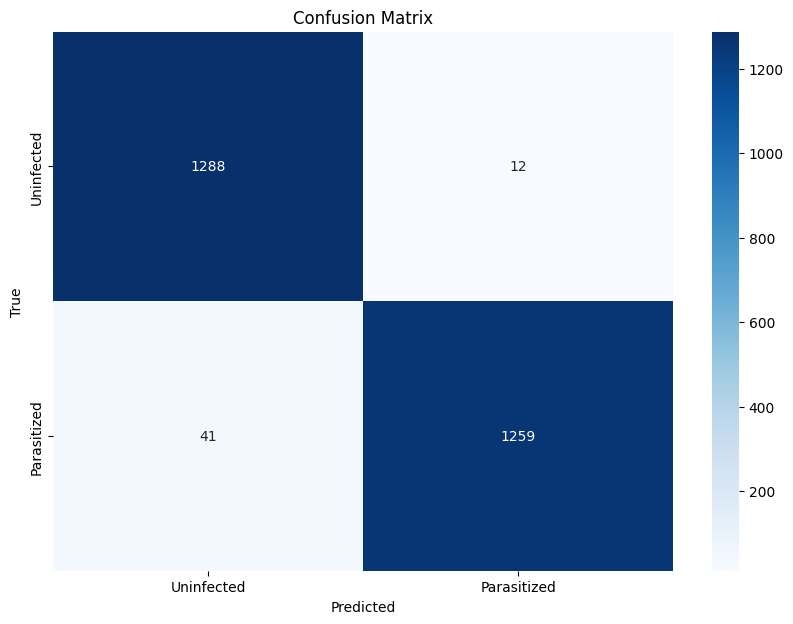

```python
# Set the seed to a fixed value
torch.manual_seed(42)

cm, _ = model_2.evaluate_model(test_dataloader_custom, device)
class_names = ["Uninfected", "Parasitized"]
model_2.plot_confusion_matrix(cm, class_names)
```

**Plotting the train and validation accuracy**

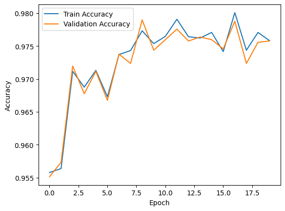

```python
# Set the seed to a fixed value
torch.manual_seed(42)

model_2.plot_accuracy_curves(train_accuracies, val_accuracies)
```

### **Think About It :**

- Can we improve the model with Image Data Augmentation?
- References to image data augmentation can be seen below:
  - [Image Augmentation for Computer Vision](https://www.mygreatlearning.com/blog/understanding-data-augmentation/)
  - [How to Configure Image Data Augmentation in Keras?](https://machinelearningmastery.com/how-to-configure-image-data-augmentation-when-training-deep-learning-neural-networks/)

### **Model 3 with Data Augmentation**

```python
# Set the seed to a fixed value
torch.manual_seed(42)

train_transforms_aug = transforms.Compose([
    transforms.Resize((64, 64)),
    transforms.TrivialAugmentWide(num_magnitude_bins=16), # how intense
    transforms.ToTensor() # use ToTensor() last to get everything between 0 & 1
])
```

### **Use image data generator**

```python
# Set the seed to a fixed value
torch.manual_seed(42)

train_data_aug = ImageFolderCustom(targ_dir=path_to_train,
                                   transform=train_transforms_aug)

train_ratio = 0.8
train_len = int(train_ratio * len(train_data_aug))
val_len = len(train_data_aug) - train_len
train_data_aug, val_data_aug = random_split(train_data_aug, [train_len, val_len])

train_dataloader_aug = DataLoader(dataset=train_data_aug,
                                  batch_size=BATCH_SIZE,
                                  num_workers=NUM_WORKERS,
                                  shuffle=True)

val_dataloader_aug = DataLoader(val_data_aug,
                                batch_size=BATCH_SIZE,
                                num_workers=NUM_WORKERS,
                                shuffle=False)
```

### **Think About It :**

- Check if the performance of the model can be improved by changing different parameters in the ImageDataGenerator.

#### **Visualizing Augmented images**

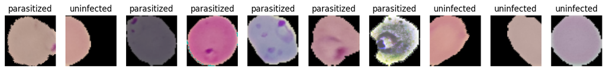

```python
display_random_images(dataset=train_data_aug,
                      classes=["uninfected", "parasitized"],
                      n=10,
                      display_shape=False,
                      seed=42)
```

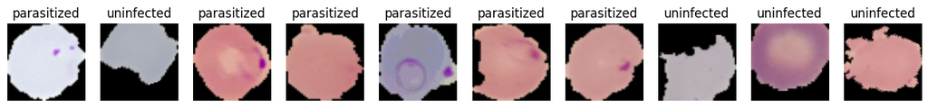

```python
display_random_images(dataset=val_data_aug,
                      classes=["uninfected", "parasitized"],
                      n=10,
                      display_shape=False,
                      seed=42)
```

#### **Observations and insights:**

- Model 1 addresses the key question of "Which classification metric is the most relevant for selecting the best deep learning model?".

  Recall is the ratio of true positive predictions to the sum of true positive and false negative predictions. It measures the ability of the model to identify all positive cases (i.e., malaria-infected samples). Another candidate metric is Area Under the Receiver Operating Characteristic (ROC-AUC) curve. This metric considers the trade-off between true positive rate (sensitivity) and false positive rate (1-specificity) for different threshold values. A higher AUC value indicates better classification performance.

  In the context of malaria diagnosis, it is crucial to minimize false negatives (i.e., malaria cases that are not identified), as this could lead to delayed treatment and potentially severe consequences. Therefore, prioritizing recall (sensitivity) might be more relevant. However, it is also important to consider the trade-off between recall and precision to avoid overdiagnosis and unnecessary treatment.

  Taken together, recall seems to be the best metric to choose since the priority is more on minimizing false negatives.
- Model 2 addresses the key question of "Which deep learning technique best solves the problem?" with a complex multi-layered design of convolutional network suggested in reference [4] and improved with LeakyReLU to combat vanishing gradients and Batch Normalization to reduce the internal covariate shift and make training more stable and efficient.

  Internal covariate shift refers to the change in the distribution of layer inputs that happens during training as the parameters of the previous layers change. This can cause the network to converge slowly or not at all, and can also lead to the saturation of activation functions.

  Additionally, batch normalization can act as a regularizer, helping to prevent overfitting and improving the generalization performance of the model.

  Indeed, model 2 shows increased performance in comparison with the previous two.
- Model 3 addresses the key question of "Does data augmentation improve the model's performance?" by applying TrivialDataAugment(). Research shows that random transforms generally perform better than hand-picked transforms. For trivial data augment, a number of transforms is randomly picked from a set of transforms to perform on an image and at a random magnitude between a given range (a higher magnitude means more instense).

### **Fit and Train the model**

```python
# Set the seed to a fixed value
torch.manual_seed(42)

# Set the flag to True
torch.backends.cudnn.deterministic = True

device = torch.device("cuda" if torch.cuda.is_available() else "cpu")
num_classes = 2  # Number of classes in the classification task
model_2 = Complex2CNN(num_classes)

criterion = nn.CrossEntropyLoss()
optimizer = optim.Adam(model_2.parameters(), lr=0.001)
num_epochs = 20

summary(model_2, input_size=(32, 3, 64, 64))
```

```
==========================================================================================
Layer (type:depth-idx)                   Output Shape              Param #
==========================================================================================
Complex2CNN                              [32, 2]                   --
├─Conv2d: 1-1                            [32, 18, 66, 66]          504
├─BatchNorm2d: 1-2                       [32, 18, 66, 66]          36
├─LeakyReLU: 1-3                         [32, 18, 66, 66]          --
├─MaxPool2d: 1-4                         [32, 18, 33, 33]          --
├─Dropout2d: 1-5                         [32, 18, 33, 33]          --
├─Conv2d: 1-6                            [32, 72, 31, 31]          11,736
├─BatchNorm2d: 1-7                       [32, 72, 31, 31]          144
├─LeakyReLU: 1-8                         [32, 72, 31, 31]          --
├─MaxPool2d: 1-9                         [32, 72, 15, 15]          --
├─Dropout2d: 1-10                        [32, 72, 15, 15]          --
├─Conv2d: 1-11                           [32, 72, 13, 13]          46,728
├─BatchNorm2d: 1-12                      [32, 72, 13, 13]          144
├─LeakyReLU: 1-13                        [32, 72, 13, 13]          --
├─MaxPool2d: 1-14                        [32, 72, 6, 6]            --
├─Dropout2d: 1-15                        [32, 72, 6, 6]            --
├─Conv2d: 1-16                           [32, 72, 4, 4]            46,728
├─BatchNorm2d: 1-17                      [32, 72, 4, 4]            144
├─LeakyReLU: 1-18                        [32, 72, 4, 4]            --
├─MaxPool2d: 1-19                        [32, 72, 2, 2]            --
├─Dropout2d: 1-20                        [32, 72, 2, 2]            --
├─Flatten: 1-21                          [32, 288]                 --
├─Linear: 1-22                           [32, 72]                  20,808
├─BatchNorm1d: 1-23                      [32, 72]                  144
├─LeakyReLU: 1-24                        [32, 72]                  --
├─Dropout: 1-25                          [32, 72]                  --
├─Linear: 1-26                           [32, 2]                   146
├─Softmax: 1-27                          [32, 2]                   --
==========================================================================================
Total params: 127,262
Trainable params: 127,262
Non-trainable params: 0
Total mult-adds (M): 708.48
==========================================================================================
Input size (MB): 1.57
Forward/backward pass size (MB): 82.43
Params size (MB): 0.51
Estimated Total Size (MB): 84.51
==========================================================================================
```

```python
# Set the seed to a fixed value
torch.manual_seed(42)

with suppress(AssertionError):
  train_accuracies, val_accuracies = model_2.train_model(train_dataloader_aug, val_dataloader_aug, criterion, optimizer, device, num_epochs)
```

```
Accuracy: 0.8687
Precision: 0.8900
Recall: 0.8687
F1 Score: 0.8671
Accuracy: 0.8698
Precision: 0.8905
Recall: 0.8698
F1 Score: 0.8680
Epoch [1/20] Train Accuracy: 0.8687, Val Accuracy: 0.8698
Accuracy: 0.8977
Precision: 0.9074
Recall: 0.8977
F1 Score: 0.8972
Accuracy: 0.8960
Precision: 0.9049
Recall: 0.8960
F1 Score: 0.8954
Epoch [2/20] Train Accuracy: 0.8977, Val Accuracy: 0.8960
Accuracy: 0.8998
Precision: 0.9128
Recall: 0.8998
F1 Score: 0.8991
Accuracy: 0.9030
Precision: 0.9142
Recall: 0.9030
F1 Score: 0.9024
Epoch [3/20] Train Accuracy: 0.8998, Val Accuracy: 0.9030
Accuracy: 0.9077
Precision: 0.9168
Recall: 0.9077
F1 Score: 0.9073
Accuracy: 0.9089
Precision: 0.9186
Recall: 0.9089
F1 Score: 0.9083
Epoch [4/20] Train Accuracy: 0.9077, Val Accuracy: 0.9089
Accuracy: 0.9037
Precision: 0.9130
Recall: 0.9037
F1 Score: 0.9033
```

[output cut: 125 more lines]

```
F1 Score: 0.9282
Accuracy: 0.9219
Precision: 0.9265
Recall: 0.9219
F1 Score: 0.9216
Epoch [19/20] Train Accuracy: 0.9283, Val Accuracy: 0.9219
Accuracy: 0.9189
Precision: 0.9259
Recall: 0.9189
F1 Score: 0.9186
Accuracy: 0.9205
Precision: 0.9268
Recall: 0.9205
F1 Score: 0.9202
Epoch [20/20] Train Accuracy: 0.9189, Val Accuracy: 0.9205
```

### **Evaluating the model**

```
Accuracy: 0.9719
Precision: 0.9723
Recall: 0.9719
F1 Score: 0.9719
```

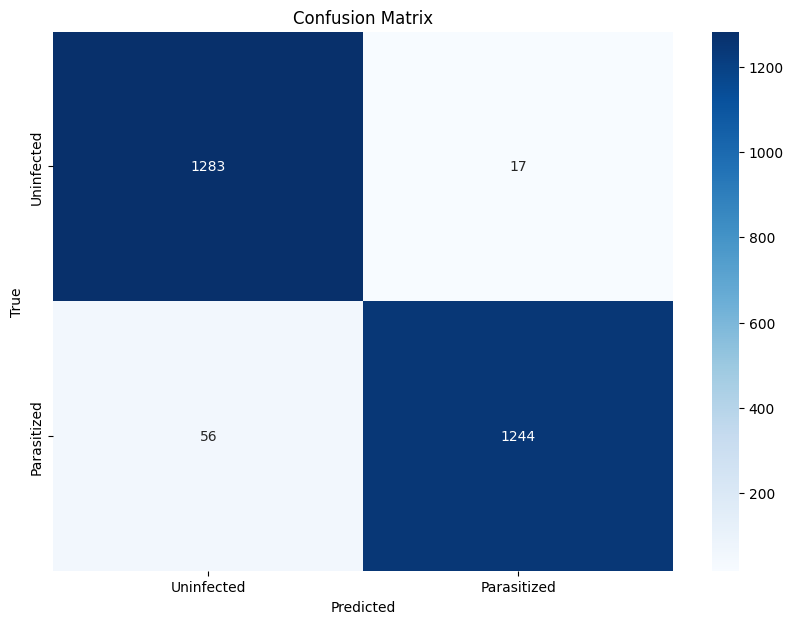

```python
# Set the seed to a fixed value
torch.manual_seed(42)

cm, _ = model_2.evaluate_model(test_dataloader_custom, device)
class_names = ["Uninfected", "Parasitized"]
model_2.plot_confusion_matrix(cm, class_names)
```

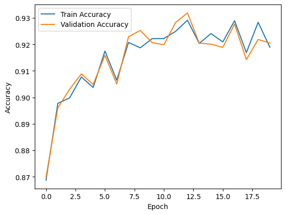

```python
# Set the seed to a fixed value
torch.manual_seed(42)

model_2.plot_accuracy_curves(train_accuracies, val_accuracies)
```

**Now, let us try to use a pretrained model like VGG16 and check how it performs on our data.**

### **Pre-trained model (VGG16)**

- Import VGG16 network upto any layer you choose
- Add Fully Connected Layers on top of it

```python
class VGG16(nn.Module):
    def __init__(self, num_classes):
        super(VGG16, self).__init__()
        self.vgg16 = models.vgg16(pretrained=True)
        self.vgg16.classifier[6] = nn.Linear(4096, num_classes)

    def forward(self, x):
        x = self.vgg16(x)
        return x

    def train_model(self, train_loader, val_loader, criterion, optimizer, device, num_epochs):
        "Trains the model and stores accuracies for train and validation data loaders for each epoch."
        self.to(device)
        train_accuracies = []
        val_accuracies = []

        for epoch in range(num_epochs):
            self.train()
            running_loss = 0.0

            # Train
            for i, (inputs, labels) in enumerate(train_loader):
                inputs, labels = inputs.to(device), labels.to(device)
                optimizer.zero_grad()
                outputs = self(inputs)
                loss = criterion(outputs, labels)
                loss.backward()
                optimizer.step()
                running_loss += loss.item()


            _, train_accuracy = self.evaluate_model(train_loader, device)
            _, val_accuracy = self.evaluate_model(val_loader, device)

            train_accuracies.append(train_accuracy)
            val_accuracies.append(val_accuracy)

            print(f"Epoch [{epoch + 1}/{num_epochs}] Train Accuracy: {train_accuracy:.4f}, Val Accuracy: {val_accuracy:.4f}")

        return train_accuracies, val_accuracies

    def evaluate_model(self, test_loader, device):
        "Evaluates the model with basic performance metrics and confusion matrix."
        self.eval()
        self.to(device)
        all_labels = []
        all_predicted = []

        with torch.no_grad():
            for inputs, labels in test_loader:
                inputs, labels = inputs.to(device), labels.to(device)
                outputs = self(inputs)
                _, predicted = torch.max(outputs.data, 1)
                all_labels.extend(labels.cpu().numpy())
                all_predicted.extend(predicted.cpu().numpy())

        accuracy = (np.array(all_labels) == np.array(all_predicted)).mean()
        precision, recall, f1_score, _ = precision_recall_fscore_support(all_labels, all_predicted, average='weighted')
        cm = confusion_matrix(all_labels, all_predicted)

        print(f"Accuracy: {accuracy:.4f}")
        print(f"Precision: {precision:.4f}")
        print(f"Recall: {recall:.4f}")
        print(f"F1 Score: {f1_score:.4f}")

        return cm, accuracy

    def plot_accuracy_curves(self, train_accuracies, val_accuracies):
        "Plots accuracy curves."
        plt.figure()
        plt.plot(train_accuracies, label='Train Accuracy')
        plt.plot(val_accuracies, label='Validation Accuracy')
        plt.xlabel('Epoch')
        plt.ylabel('Accuracy')
        plt.legend()
        plt.show()

    def plot_confusion_matrix(self, cm, class_names):
        "Plots confusion matrices."
        plt.figure(figsize=(10, 7))
        sns.heatmap(cm, annot=True, fmt="d", cmap="Blues", xticklabels=class_names, yticklabels=class_names)
        plt.xlabel("Predicted")
        plt.ylabel("True")
        plt.title("Confusion Matrix")
        plt.show()
```

### **Fit and Train the model**

```python
# Set the seed to a fixed value
torch.manual_seed(42)

# Set the flag to True
torch.backends.cudnn.deterministic = True

device = torch.device("cuda" if torch.cuda.is_available() else "cpu")
vgg16_model = VGG16(num_classes=2)

criterion = nn.CrossEntropyLoss()
optimizer = optim.Adam(vgg16_model.parameters(), lr=0.001)
num_epochs = 10

summary(vgg16_model, input_size=(32, 3, 64, 64))
```

```
==========================================================================================
Layer (type:depth-idx)                   Output Shape              Param #
==========================================================================================
VGG16                                    [32, 2]                   --
├─VGG: 1-1                               [32, 2]                   --
│    └─Sequential: 2-1                   [32, 512, 2, 2]           --
│    │    └─Conv2d: 3-1                  [32, 64, 64, 64]          1,792
│    │    └─ReLU: 3-2                    [32, 64, 64, 64]          --
│    │    └─Conv2d: 3-3                  [32, 64, 64, 64]          36,928
│    │    └─ReLU: 3-4                    [32, 64, 64, 64]          --
│    │    └─MaxPool2d: 3-5               [32, 64, 32, 32]          --
│    │    └─Conv2d: 3-6                  [32, 128, 32, 32]         73,856
│    │    └─ReLU: 3-7                    [32, 128, 32, 32]         --
│    │    └─Conv2d: 3-8                  [32, 128, 32, 32]         147,584
│    │    └─ReLU: 3-9                    [32, 128, 32, 32]         --
│    │    └─MaxPool2d: 3-10              [32, 128, 16, 16]         --
│    │    └─Conv2d: 3-11                 [32, 256, 16, 16]         295,168
│    │    └─ReLU: 3-12                   [32, 256, 16, 16]         --
│    │    └─Conv2d: 3-13                 [32, 256, 16, 16]         590,080
│    │    └─ReLU: 3-14                   [32, 256, 16, 16]         --
│    │    └─Conv2d: 3-15                 [32, 256, 16, 16]         590,080
│    │    └─ReLU: 3-16                   [32, 256, 16, 16]         --
│    │    └─MaxPool2d: 3-17              [32, 256, 8, 8]           --
│    │    └─Conv2d: 3-18                 [32, 512, 8, 8]           1,180,160
│    │    └─ReLU: 3-19                   [32, 512, 8, 8]           --
│    │    └─Conv2d: 3-20                 [32, 512, 8, 8]           2,359,808
│    │    └─ReLU: 3-21                   [32, 512, 8, 8]           --
│    │    └─Conv2d: 3-22                 [32, 512, 8, 8]           2,359,808
│    │    └─ReLU: 3-23                   [32, 512, 8, 8]           --
│    │    └─MaxPool2d: 3-24              [32, 512, 4, 4]           --
│    │    └─Conv2d: 3-25                 [32, 512, 4, 4]           2,359,808
│    │    └─ReLU: 3-26                   [32, 512, 4, 4]           --
│    │    └─Conv2d: 3-27                 [32, 512, 4, 4]           2,359,808
│    │    └─ReLU: 3-28                   [32, 512, 4, 4]           --
│    │    └─Conv2d: 3-29                 [32, 512, 4, 4]           2,359,808
│    │    └─ReLU: 3-30                   [32, 512, 4, 4]           --
│    │    └─MaxPool2d: 3-31              [32, 512, 2, 2]           --
│    └─AdaptiveAvgPool2d: 2-2            [32, 512, 7, 7]           --
│    └─Sequential: 2-3                   [32, 2]                   --
│    │    └─Linear: 3-32                 [32, 4096]                102,764,544
│    │    └─ReLU: 3-33                   [32, 4096]                --
│    │    └─Dropout: 3-34                [32, 4096]                --
│    │    └─Linear: 3-35                 [32, 4096]                16,781,312
│    │    └─ReLU: 3-36                   [32, 4096]                --
│    │    └─Dropout: 3-37                [32, 4096]                --
│    │    └─Linear: 3-38                 [32, 2]                   8,194
==========================================================================================
Total params: 134,268,738
Trainable params: 134,268,738
Non-trainable params: 0
Total mult-adds (G): 43.95
==========================================================================================
Input size (MB): 1.57
Forward/backward pass size (MB): 285.21
Params size (MB): 537.07
Estimated Total Size (MB): 823.86
==========================================================================================
```

```python
# Set the seed to a fixed value
torch.manual_seed(42)

with suppress(AssertionError):
  train_accuracies, val_accuracies = vgg16_model.train_model(train_dataloader_custom, val_dataloader_custom, criterion=criterion, optimizer=optimizer, device=device, num_epochs=num_epochs)
```

```
Accuracy: 0.5057
Precision: 0.2557
Recall: 0.5057
F1 Score: 0.3396
Accuracy: 0.4980
Precision: 0.2480
Recall: 0.4980
F1 Score: 0.3311
Epoch [1/10] Train Accuracy: 0.5057, Val Accuracy: 0.4980
Accuracy: 0.5057
Precision: 0.2557
Recall: 0.5057
F1 Score: 0.3396
Accuracy: 0.4980
Precision: 0.2480
Recall: 0.4980
F1 Score: 0.3311
Epoch [2/10] Train Accuracy: 0.5057, Val Accuracy: 0.4980
Accuracy: 0.5057
Precision: 0.2557
Recall: 0.5057
F1 Score: 0.3396
Accuracy: 0.4980
Precision: 0.2480
Recall: 0.4980
F1 Score: 0.3311
Epoch [3/10] Train Accuracy: 0.5057, Val Accuracy: 0.4980
Accuracy: 0.5057
Precision: 0.2557
Recall: 0.5057
F1 Score: 0.3396
Accuracy: 0.4980
Precision: 0.2480
Recall: 0.4980
F1 Score: 0.3311
Epoch [4/10] Train Accuracy: 0.5057, Val Accuracy: 0.4980
Accuracy: 0.5057
Precision: 0.2557
Recall: 0.5057
F1 Score: 0.3396
```

[output cut: 35 more lines]

```
F1 Score: 0.3396
Accuracy: 0.4980
Precision: 0.2480
Recall: 0.4980
F1 Score: 0.3311
Epoch [9/10] Train Accuracy: 0.5057, Val Accuracy: 0.4980
Accuracy: 0.5057
Precision: 0.2557
Recall: 0.5057
F1 Score: 0.3396
Accuracy: 0.4980
Precision: 0.2480
Recall: 0.4980
F1 Score: 0.3311
Epoch [10/10] Train Accuracy: 0.5057, Val Accuracy: 0.4980
```

**Plot the train and validation accuracy**

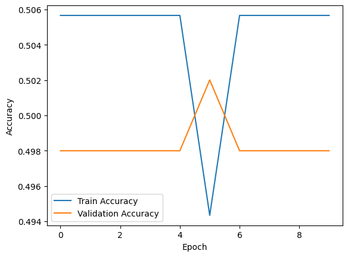

```python
# Set the seed to a fixed value
torch.manual_seed(42)

vgg16_model.plot_accuracy_curves(train_accuracies, val_accuracies)
```

### **Observations and insights:**

Unfortunately, model VGG16 does not seem to converge well, underfitting drastically. It would need more work to be done.

- What can be observed from the validation and train curves?

### **Evaluating the model**

**Plotting the classification report and confusion matrix**

```
Accuracy: 0.5000
Precision: 0.2500
Recall: 0.5000
F1 Score: 0.3333
```

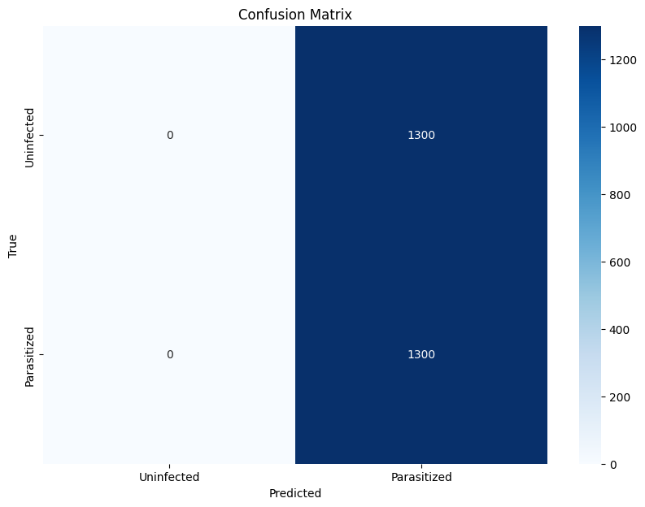

```python
# Set the seed to a fixed value
torch.manual_seed(42)

cm, _ = vgg16_model.evaluate_model(test_dataloader_custom, device)
class_names = ["Uninfected", "Parasitized"]  # Replace with your actual class names
vgg16_model.plot_confusion_matrix(cm, class_names)
```

### **Think about it:**

- What observations and insights can be drawn from the confusion matrix and classification report?
- Choose the model with the best accuracy scores from all the above models and save it as a final model.

**Improvements that can be done:**

#### **Refined insights**:

- What are the most meaningful insights from the data relevant to the problem?
  - There are 24,958 train images (19,966 after splitting off the validation set of 4,992) and 2,600 test images. The data are balanced for each class for each data set. The range and distribution of pixel values do not differ significantly between classes.
  - The parasites can be of various shapes and their color can be mistaken for red blood cell impurities. The key role of color is confirmed both by mean images for each class and HSV conversion that separates parasites very well. Moreover, it's robust against changes in brightness and lighting.
  - Gaussian blurring seems to remove the sharp definition of parasites which could lead to false negatives in smaller parasite bodies.

#### **Comparison of various techniques and their relative performance**:

- How do different techniques perform? Which one is performing relatively better? Is there scope to improve the performance further?
  - The simple model performs relatively well. Increasing the depth of the convolutional layers leads to more instability in the training, presumably due to vanishing gradients. LeakyReLU and batch normalization improve the instability. Unfortunately, the pre-trained model VGG16 did not perform very well, underfitting severely, and would need more tuning.
  - Improvements can be introduced according to the list above.